# Principios de Estadística Aplicada con R

Introducción a R

Gabriel Carrasco Escobar

Universidad Peruana Cayetano Heredia

Jorge Ruiz Cabrejos

Universidad Peruana Cayetano Heredia

08 de febrero del 2018

Rutinas y comandos complementarios del curso *Principios de Estadística Aplicada con R (PEAR)*

*Cualquier problema con este código, porfavor contactar a gabriel.carrasco@upch.pe*

Los paquetes a ser utilizados en esta sección son:

```r
library(devtools)
library(rafalib)
library(downloader)
library(dplyr)
```

## Introducción a R

La consola de RStudio es el área de trabajo en donde se ejecutan operaciones, funciones y códigos con R, desarrollado por R Development Core Team (2008).

Por ejemplo, podemos utilizarlo para llevar a cabo operaciones aritméticas como:

```r
10*10
```

```
## [1] 100
```

```r
420/30
```

```
## [1] 14
```

O crear vectores (secuencia ordenada de elementos de un mismo tipo):

```r
1:10
```

```
##  [1]  1  2  3  4  5  6  7  8  9 10
```

```r
c("Juan","Carlos","Gabriel")
```

```
## [1] "Juan"    "Carlos"  "Gabriel"
```

### Objetos

Un objeto es una estructura que almacena las características y datos que se le asigne. Es asi que se dice que R es un lenguaje de programación orientado a objetos.

A continuación, generamos un vector con números enteros del 1 al 10

```r
1:10
```

```
##  [1]  1  2  3  4  5  6  7  8  9 10
```

Ahora, asignamos este vector a un objeto al cual llamaremos `x`

```r
x<-1:10
x
```

```
##  [1]  1  2  3  4  5  6  7  8  9 10
```

Así, el objeto `x` almacenará este vector

### Funciones

Las funciones son operaciones o procedimientos desarrollados por la comunidad de R. Por ejemplo, la función `rnorm` nos permite generar una muestra de números racionales aleatorios con distribución normal.

Utilizando esta función, asignaremos 10 números generados aleatoriamente al objeto `y`

```r
y=rnorm(10)
y
```

```
##  [1] -2.09240639 -0.23971290 -2.11148759  0.50933859 -0.35078262
##  [6]  0.23927626 -0.17203897  0.13447329  0.04048101 -1.87405936
```

Ahora, utilizando ambos objetos antes creados (`x` e `y`), utilizamos la función `plot` para graficar los datos.

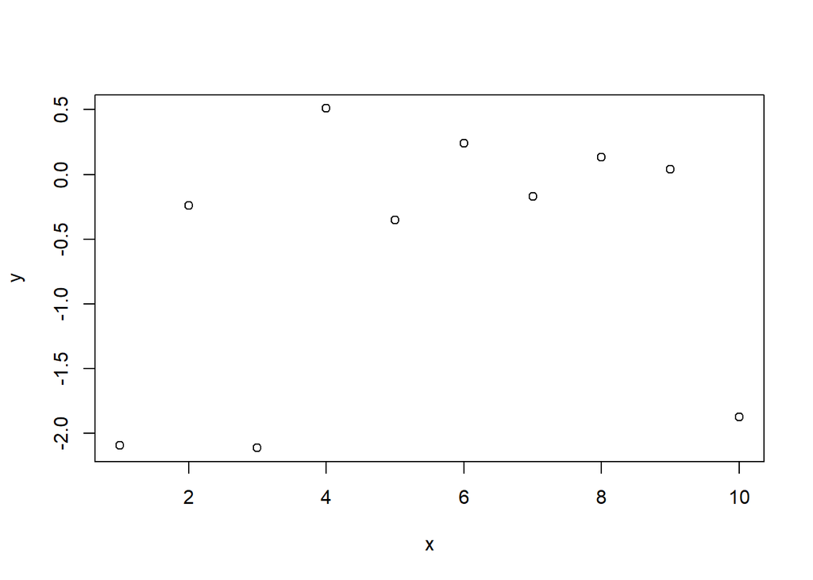

```r
plot(x,y)
```

Añadiendo `col = "color"` podemos modificar el color del gráfico, especificando el color dentro del doble corchete. En el ejemplo a continuación, colocamos el color `blueviolet`

*[Lista de colores disponibles en R](http://www.stat.columbia.edu/~tzheng/files/Rcolor.pdf)* por @tzheng_color

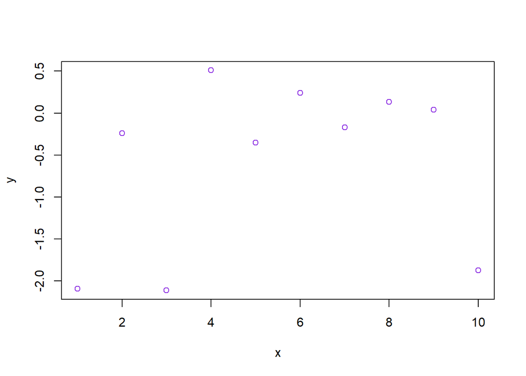

```r
plot(x,y, col= "blueviolet")
```

## Importando datos

### Datasets

R puede utilizar bases de datos externas (Excel, Stata, SPSS, etc.) Para importar esta información a la consola, primero debemos establecer nuestro directorio de trabajo. Aqui almacenaremos nuestras bases de datos, scripts y archivos a ser utilizados.

```r
setwd("C:/Usuario/Estudiante/Escritorio/Estadistica")
```

A continuación, cargaremos la base de datos `femaleMiceWeights.csv` de Love (2015) y lo almacenaremos dentro del objeto `dat`. Para lograrlo, se puede importar de tres formas distintas:

1.- En la barra superior, entrando a File > Import Dataset y seleccionando el tipo de archivo a instalar

[figure not shown]

2.- Utilizando `read.csv`

```r
dat <- read.csv("C:/Usuario/Estudiante/Escritorio/Estadistica/Databases/femaleMiceWeights.csv")
```

3.- Utilizando `file.choose()`

```r
dat <- read.csv(file.choose())
```

### Download

Esta base de datos (`femaleMiceWeights.csv`) es de acceso libre y puede ser descargada directamente desde su repositorio con la función `download`. El archivo se descargara en el directorio de trabajo

```r
url <- "https://raw.githubusercontent.com/genomicsclass/dagdata/master/inst/extdata/femaleMiceWeights.csv"
filename <- "femaleMiceWeights2.csv"
download(url, destfile=filename)
```

Para conocer el directorio de trabajo actual (en donde la función `download` a realizado la descarga) se puede utilizar la función `getwd()`

### Visualización de una base

Para visualizar parte de la tabla importada en R, utilizamos la función `head`

```r
head(dat)
```

```
##   Diet Bodyweight
## 1 chow      21.51
## 2 chow      28.14
## 3 chow      24.04
## 4 chow      23.45
## 5 chow      23.68
## 6 chow      19.79
```

Para visualizar todos los datos de la tabla importada en R, utilizamos la función `view`

```r
View(dat)
```

| Diet | Bodyweight |
| --- | --- |
| chow | 21.51 |
| chow | 28.14 |
| chow | 24.04 |
| chow | 23.45 |
| chow | 23.68 |
| chow | 19.79 |
| chow | 28.40 |
| chow | 20.98 |
| chow | 22.51 |
| chow | 20.10 |
| chow | 26.91 |
| chow | 26.25 |
| hf | 25.71 |
| hf | 26.37 |
| hf | 22.80 |
| hf | 25.34 |
| hf | 24.97 |
| hf | 28.14 |
| hf | 29.58 |
| hf | 30.92 |
| hf | 34.02 |
| hf | 21.90 |
| hf | 31.53 |
| hf | 20.73 |

## Tipo de datos en R

Existen cuatro tipos de objetos básicos en R

### Vector

Serie de elementos del mismo tipo (dimensión 1)

```r
vector <- seq(1, 100, by =3)
vector
```

```
##  [1]   1   4   7  10  13  16  19  22  25  28  31  34  37  40  43  46  49
## [18]  52  55  58  61  64  67  70  73  76  79  82  85  88  91  94  97 100
```

### Lista

Contiene una selección de objetos heterogéneos

```r
lista <- list(name="Mike", gender="M", company ="ProgramCreek")
lista
```

```
## $name
## [1] "Mike"
##
## $gender
## [1] "M"
##
## $company
## [1] "ProgramCreek"
```

### Matriz

Extensión de vectores de 2 dimensiones

```r
mat <- rbind(c(1,2,3),c(4,5,6))
mat
```

```
##      [,1] [,2] [,3]
## [1,]    1    2    3
## [2,]    4    5    6
```

### Data Frame

Una matriz con nombres de columnas (variables) y que puede incluir variables no numéricas

```r
df <- data.frame(a=c(1,2,3,4,5), b=c(1,2,3,4,5))
df
```

```
##   a b
## 1 1 1
## 2 2 2
## 3 3 3
## 4 4 4
## 5 5 5
```

### Identificación de objetos

La función `class` nos permite identificar el tipo de dato de un objeto. En este caso, `dat` es un data.frame

```r
class(dat)
```

```
## [1] "data.frame"
```